# BIO532 Hypothesis-testing with Sampling Distributions for Linear Model Statistics

Michal L Collyer

```r
knitr::opts_chunk$set(echo = TRUE)
```

### Note that this HTML version has a lot of detail and the pure R script has little. This document adds note; the other just has the steps.

# Review of the Rattlesnake Example

```r
set.seed(21) # This is a trick to set the seed for random numbers (not needed)
```

Recall, the data and example linear model statistics from the previous chapter.

```r
y <- c(rnorm(10, mean = 0.9, sd = 0.2), rnorm(10, mean = 0.6, sd = 0.2))
group1 <- factor(c(rep("Mexico", 10), rep("USA", 10)),
                 levels = c("Mexico", "USA"))

df <- data.frame(y = y, group1 = group1)

df
```

```
##            y group1
## 1  1.0586026 Mexico
## 2  1.0044503 Mexico
## 3  1.2492444 Mexico
## 4  0.6457328 Mexico
## 5  1.3394779 Mexico
## 6  0.9866262 Mexico
## 7  0.5859601 Mexico
## 8  0.7130189 Mexico
## 9  0.9126987 Mexico
## 10 0.8995213 Mexico
## 11 0.1446438    USA
## 12 0.7514824    USA
## 13 0.4903189    USA
## 14 0.6345099    USA
## 15 0.7125706    USA
## 16 0.9023636    USA
## 17 0.7318050    USA
## 18 0.8244056    USA
## 19 0.4430717    USA
## 20 0.5148615    USA
```

# Linear Model Statistics

The estimation of coefficients (fitting of the model) can be performed with the `lm` function in `R`.

```r
fit0 <- lm(y ~ 1, data = df)
fit1 <- lm(y ~ group1, data = df)

fit0
```

```
##
## Call:
## lm(formula = y ~ 1, data = df)
##
## Coefficients:
## (Intercept)
##      0.7773
```

```r
fit1
```

```
##
## Call:
## lm(formula = y ~ group1, data = df)
##
## Coefficients:
## (Intercept)    group1USA
##      0.9395      -0.3245
```

We can see what the model matrices look like by using the `model.matrix` function.

```r
X0 <- model.matrix(fit0)
X1 <- model.matrix(fit1)

X0
```

```
##    (Intercept)
## 1            1
## 2            1
## 3            1
## 4            1
## 5            1
## 6            1
## 7            1
## 8            1
## 9            1
## 10           1
## 11           1
## 12           1
## 13           1
## 14           1
## 15           1
## 16           1
## 17           1
## 18           1
## 19           1
## 20           1
## attr(,"assign")
## [1] 0
```

```r
X1
```

```
##    (Intercept) group1USA
## 1            1         0
## 2            1         0
## 3            1         0
## 4            1         0
## 5            1         0
## 6            1         0
## 7            1         0
## 8            1         0
## 9            1         0
## 10           1         0
## 11           1         1
## 12           1         1
## 13           1         1
## 14           1         1
## 15           1         1
## 16           1         1
## 17           1         1
## 18           1         1
## 19           1         1
## 20           1         1
## attr(,"assign")
## [1] 0 1
## attr(,"contrasts")
## attr(,"contrasts")$group1
## [1] "contr.treatment"
```

The `coef`, `fitted`, and `resid` functions allow us to observe coefficients, fitted values, and residuals, respectively.

```r
coef(fit0)
```

```
## (Intercept)
##   0.7772683
```

```r
coef(fit1)
```

```
## (Intercept)   group1USA
##   0.9395333  -0.3245300
```

```r
fitted(fit0)
```

```
##         1         2         3         4         5         6         7         8
## 0.7772683 0.7772683 0.7772683 0.7772683 0.7772683 0.7772683 0.7772683 0.7772683
##         9        10        11        12        13        14        15        16
## 0.7772683 0.7772683 0.7772683 0.7772683 0.7772683 0.7772683 0.7772683 0.7772683
##        17        18        19        20
## 0.7772683 0.7772683 0.7772683 0.7772683
```

```r
fitted(fit1)
```

```
##         1         2         3         4         5         6         7         8
## 0.9395333 0.9395333 0.9395333 0.9395333 0.9395333 0.9395333 0.9395333 0.9395333
##         9        10        11        12        13        14        15        16
## 0.9395333 0.9395333 0.6150033 0.6150033 0.6150033 0.6150033 0.6150033 0.6150033
##        17        18        19        20
## 0.6150033 0.6150033 0.6150033 0.6150033
```

```r
resid(fit0)
```

```
##           1           2           3           4           5           6
##  0.28133432  0.22718194  0.47197614 -0.13153554  0.56220960  0.20935784
##           7           8           9          10          11          12
## -0.19130824 -0.06424944  0.13543036  0.12225302 -0.63262456 -0.02578587
##          13          14          15          16          17          18
## -0.28694942 -0.14275842 -0.06469770  0.12509528 -0.04546328  0.04713730
##          19          20
## -0.33419658 -0.26240677
```

```r
resid(fit1)
```

```
##           1           2           3           4           5           6
##  0.11906932  0.06491694  0.30971114 -0.29380054  0.39994460  0.04709284
##           7           8           9          10          11          12
## -0.35357324 -0.22651444 -0.02683464 -0.04001198 -0.47035956  0.13647913
##          13          14          15          16          17          18
## -0.12468442  0.01950659  0.09756730  0.28736028  0.11680172  0.20940230
##          19          20
## -0.17193158 -0.10014177
```

We can use the residuals – the lack of fit and, therefore, the imprecision of the models – to estimate model error.

```r
e0 <- resid(fit0)
e1 <- resid(fit1)

RSS0 <- crossprod(e0)
RSS1 <- crossprod(e1)

RSS0
```

```
##          [,1]
## [1,] 1.513015
```

```r
RSS1
```

```
##           [,1]
## [1,] 0.9864163
```

# Model-Comparison Statistics

Model-comparison statistics compare null and alternative models.

The difference in nested model error is proportional to the **effect** of adding parameters for the variable, *group1*, to the null model. We can measure the *group1* effect as the sum of squared differences in model predictions.

```r
SS1 <- RSS0 - RSS1

SS1
```

```
##           [,1]
## [1,] 0.5265986
```

It is a little more straightforward to express *SS* as a proportion of the overall variation in the data, using the **coefficient of determination**.

```r
Rsq1 <- SS1 / RSS0

Rsq1
```

```
##           [,1]
## [1,] 0.3480459
```

We can also calculate a statistic that rather than representing the portion of $RSS_0$, averages the amount of variation explained by the parameters in $\mathbf{X}_1$ relative to the amount of variation not explained by them.

```r
df1 <- ncol(X1) - ncol(X0) # degrees of freedom for the group1 1 effect

MS1 <- SS1 / df1

MS1
```

```
##           [,1]
## [1,] 0.5265986
```

```r
dfr1 <- nrow(X1) - ncol(X1) # degrees of freedom for the residuals

MSE1 <- RSS1 / dfr1

MSE1
```

```
##           [,1]
## [1,] 0.0548009
```

```r
F1 <- MS1 / MSE1

F1
```

```
##          [,1]
## [1,] 9.609305
```

# Difference between Linear Model Statistics and Model Comparison (Test) Statistics

- Obviously, linear model statistics require one linear model; model-comparison (test) statistics require two.
- As **test** statistics, model-comparisons statistics can be used in hypothesis tests.
- Hypothesis tests require a null hypothesis and the **null model** correpsonds to the null hypothesis.
- **Sampling distributions** are distributions of model-comparison (test) statistics generated from random outcomes of the null model, randomizing residuals.
- The probability of observing statistics as large as the observed statistics in their sampling distributions is evidence for rejecting or not rejecting a null hypothesis.

# RRPP: The method of generating sampling distributions

### RRPP is $\mathcal{Y} = \mathbf{Xb} + \mathbf{e}^*$

For a null model with just a vector of 1s (intercept). Randomizing residuals is tantamount to randomizing data. Same mean and same sample variance every random permutation. In later chapters we will have different null models, so we will only have constant variance.

Let’s start by stating a null hypothesis, which we can later modify for different models, but will always have the same format.

$$H_0: \sigma^2_{\beta_1, \mathbf{X}_1 | \beta_0, \mathbf{X}_0} = 0$$

$$H_1: \sigma^2_{\beta_1, \mathbf{X}_1 | \beta_0, \mathbf{X}_0} > 0$$

### How does this work?

Look at this example, with three versions of $\mathcal{Y} = \mathbf{Xb} + \mathbf{e}^*$ (the observed case counts as one permutation).

```r
y.r1 <- sample(y)
y.r2 <- sample(y)
fit1.r1 <- lm(y.r1 ~ group1)
fit1.r2 <- lm(y.r2 ~ group1)
```

```r
y  # observed (counts as one permutation)
```

```
##  [1] 1.0586026 1.0044503 1.2492444 0.6457328 1.3394779 0.9866262 0.5859601
##  [8] 0.7130189 0.9126987 0.8995213 0.1446438 0.7514824 0.4903189 0.6345099
## [15] 0.7125706 0.9023636 0.7318050 0.8244056 0.4430717 0.5148615
```

```r
y.r1 # first random permutation
```

```
##  [1] 1.0586026 0.7318050 0.5148615 0.9126987 0.8995213 1.3394779 0.7514824
##  [8] 0.7125706 0.7130189 0.4903189 0.4430717 0.9023636 1.0044503 0.1446438
## [15] 0.6457328 0.5859601 1.2492444 0.6345099 0.9866262 0.8244056
```

```r
y.r2 # second random permutation
```

```
##  [1] 0.8995213 0.7514824 0.8244056 0.4430717 0.1446438 1.0044503 1.3394779
##  [8] 0.5148615 1.0586026 0.6345099 0.7130189 0.9866262 0.6457328 0.4903189
## [15] 0.9023636 0.7125706 0.9126987 1.2492444 0.7318050 0.5859601
```

And if we calculate $RSS$ from linear model fits for $\mathcal{Y} ~ group1$, each time, and use these values to obtain $F$-statistics, we get

```r
F1 <- summary(fit1)$fstatistic[1]
F1.r1 <- summary(fit1.r1)$fstatistic[1]
F1.r2 <- summary(fit1.r2)$fstatistic[1]


F1 # observed (counts as one permutation)
```

```
##    value
## 9.609305
```

```r
F1.r1 # first random permutation
```

```
##     value
## 0.2991579
```

```r
F1.r2 # second random permutation
```

```
##      value
## 0.05933482
```

Now, repeat this **MANY** times and create distributions of this statistic (plus could do this with $SS$, $MS$, $R^2$). We will not do this one by one, but we can use a program to do it. We must first install the conveniently names `RRPP` package. On can do this with:

`install.packages("RRPP")`

Or use the drop-down tool in R-Studio.

```r
library(RRPP)

fit1.rrpp <- lm.rrpp(y ~ group1,
                     data = df,
                     print.progress = FALSE,
                     iter = 999)

coef(fit1)
```

```
## (Intercept)   group1USA
##   0.9395333  -0.3245300
```

```r
coef(fit1.rrpp)
```

```
##                   [,1]
## (Intercept)  0.9395333
## group1USA   -0.3245300
```

```r
attributes(fit1.rrpp)
```

```
## $names
## [1] "call"     "LM"       "ANOVA"    "PermInfo" "Models"
##
## $class
## [1] "lm.rrpp"
```

Notice that an `lm.rrpp` class object has several different output bins. Let’s look at the `$LM` bin.

```r
attributes(fit1.rrpp$LM)
```

```
## $names
##  [1] "form"                  "coefficients"          "ols"
##  [4] "gls"                   "Y"                     "X"
##  [7] "n"                     "p"                     "p.prime"
## [10] "QR"                    "Terms"                 "term.labels"
## [13] "data"                  "model.sets"            "random.coef"
## [16] "random.coef.distances" "fitted"                "residuals"
## [19] "mean"
```

Looks like many things we would expect!

Some example extractable components:

```r
fit1.rrpp$LM$n
```

```
## [1] 20
```

```r
fit1.rrpp$LM$coefficients
```

```
## (Intercept)   group1USA
##   0.9395333  -0.3245300
```

```r
fit1.rrpp$LM$fitted
```

```
##  [1] 0.9395333 0.9395333 0.9395333 0.9395333 0.9395333 0.9395333 0.9395333
##  [8] 0.9395333 0.9395333 0.9395333 0.6150033 0.6150033 0.6150033 0.6150033
## [15] 0.6150033 0.6150033 0.6150033 0.6150033 0.6150033 0.6150033
```

```r
fit1.rrpp$LM$residuals
```

```
##  [1]  0.11906932  0.06491694  0.30971114 -0.29380054  0.39994460  0.04709284
##  [7] -0.35357324 -0.22651444 -0.02683464 -0.04001198 -0.47035956  0.13647913
## [13] -0.12468442  0.01950659  0.09756730  0.28736028  0.11680172  0.20940230
## [19] -0.17193158 -0.10014177
```

Now let’s look at the `$ANOVA` bin.

```r
attributes(fit1.rrpp$ANOVA)
```

```
## $names
##  [1] "SS.type"   "SS"        "MS"        "RSS"       "TSS"       "RSS.model"
##  [7] "Rsq"       "Fs"        "cohenf"    "n"         "p"         "df"
```

Notice there are some familiar terms, like `SS`, `MS`, `RSS`, `Rsq`, `Fs`, `n`, and `df`. One of the unfamiliar terms, `TSS` is actually something we know; it is $RSS_0$, also known as the **total sum of squares**. Some of the other terms will become familiar later, when we get into more complex linear models.

It is important to realize that all of these objects are not single statistics. Each is an array of 1000 statistics, one for every iteration of RRPP. For example:

```r
attach(fit1.rrpp$ANOVA)
RSS
```

```
##              obs   iter.1   iter.2   iter.3   iter.4   iter.5  iter.6   iter.7
## group1 0.9864163 1.487688 1.485389 1.500985 1.401195 1.497811 1.24101 1.299031
##          iter.8   iter.9  iter.10  iter.11  iter.12  iter.13  iter.14  iter.15
## group1 1.508511 1.416567 1.406211 1.448603 1.504332 1.436464 1.460862 1.477545
##         iter.16  iter.17  iter.18  iter.19  iter.20  iter.21  iter.22  iter.23
## group1 1.369016 1.459739 1.485279 1.299446 1.503903 1.077316 1.511348 1.414426
##         iter.24  iter.25  iter.26  iter.27  iter.28  iter.29  iter.30  iter.31
## group1 1.445129 1.404873 1.481316 1.423092 1.427534 1.461701 1.479836 1.474557
##         iter.32  iter.33 iter.34  iter.35  iter.36  iter.37  iter.38  iter.39
## group1 1.511094 1.444858  1.5129 1.482072 1.506749 1.505835 1.447281 1.483531
##         iter.40  iter.41  iter.42 iter.43  iter.44  iter.45  iter.46  iter.47
## group1 1.442357 1.504819 1.483355 1.51251 1.016509 1.458898 1.343003 1.492016
##         iter.48  iter.49  iter.50  iter.51  iter.52  iter.53  iter.54 iter.55
## group1 1.202555 1.512779 1.508735 1.469445 1.383575 1.398173 1.506843 1.51208
##         iter.56  iter.57 iter.58  iter.59  iter.60  iter.61  iter.62  iter.63
## group1 1.489299 1.149177 1.46382 1.506888 1.502134 1.398039 1.428245 1.511633
##         iter.64  iter.65  iter.66  iter.67  iter.68  iter.69  iter.70  iter.71
## group1 1.431523 1.442496 1.148974 1.503811 1.512939 1.439737 1.408571 1.502885
##          iter.72  iter.73  iter.74  iter.75 iter.76  iter.77  iter.78  iter.79
## group1 0.8468915 1.512572 1.478817 1.504578 1.27335 1.371642 1.446876 1.473115
##         iter.80  iter.81  iter.82  iter.83  iter.84  iter.85  iter.86  iter.87
## group1 1.486741 1.512653 1.500274 1.456412 1.505384 1.511447 1.512989 1.505134
##         iter.88  iter.89  iter.90  iter.91  iter.92 iter.93  iter.94  iter.95
## group1 1.456392 1.230066 1.440508 1.493905 1.455419 1.47057 1.393668 1.506004
##         iter.96  iter.97  iter.98  iter.99 iter.100 iter.101 iter.102 iter.103
## group1 1.508525 1.477946 1.513014 1.475695 1.403042 1.470191 1.290931 1.232128
##        iter.104 iter.105 iter.106 iter.107 iter.108 iter.109 iter.110 iter.111
## group1 1.510905 1.418688 1.234465 1.417079 1.497019 1.457632 1.502803 1.490278
##        iter.112 iter.113 iter.114 iter.115 iter.116 iter.117 iter.118 iter.119
## group1 1.481135 1.413113  1.26988 1.450848 1.512889 1.417895 1.512263 1.440761
##        iter.120 iter.121 iter.122 iter.123 iter.124 iter.125 iter.126 iter.127
## group1 1.490238 1.435763 1.506613 1.501354 1.488355 1.459992 1.507349 1.166564
##        iter.128 iter.129 iter.130 iter.131 iter.132 iter.133 iter.134 iter.135
## group1 1.106194  1.45489 1.512635 1.473521 1.410661 1.512465 1.435929 1.444379
##        iter.136 iter.137 iter.138 iter.139 iter.140 iter.141 iter.142 iter.143
## group1 1.423889 1.512697 1.512925 1.510392 1.446396 1.440973  1.42159 1.508407
##        iter.144 iter.145 iter.146 iter.147 iter.148 iter.149 iter.150 iter.151
## group1 1.427561 1.492378 1.505496 1.467287 1.464168 1.433899 1.017529 1.404422
##        iter.152 iter.153 iter.154 iter.155 iter.156 iter.157 iter.158 iter.159
## group1 1.512836 1.338238    1.482 1.287502 1.498345 1.503387 1.482084 1.488212
```

[output cut: 195 more lines]

```
## group1 1.513013 1.512598 1.489346 1.488379 1.510375 1.304023 1.495047 1.508579
##        iter.944 iter.945 iter.946 iter.947 iter.948 iter.949 iter.950 iter.951
## group1 1.367798 1.510875 1.424701  1.51143 1.473336 1.489471 1.364108 1.493887
##        iter.952 iter.953 iter.954 iter.955 iter.956 iter.957 iter.958 iter.959
## group1 1.318683 1.486235 1.297234 1.433183 1.512843 1.511856 1.340478  1.51148
##        iter.960 iter.961 iter.962 iter.963 iter.964 iter.965 iter.966 iter.967
## group1 1.166613 1.507249 1.493466 1.512082 1.357061 1.142583 1.503954 1.507936
##        iter.968 iter.969 iter.970 iter.971 iter.972 iter.973 iter.974 iter.975
## group1 1.291067 1.506616 1.200913 1.382292 1.512862 1.513007 1.512981 1.504821
##        iter.976 iter.977 iter.978 iter.979 iter.980 iter.981 iter.982 iter.983
## group1 1.377493 1.452605 1.508243 1.511958 1.512997 1.417639 1.152496 1.492594
##        iter.984 iter.985 iter.986 iter.987 iter.988 iter.989 iter.990 iter.991
## group1 1.510085 1.513001 1.489138 1.471901 1.364475 1.512917 1.476038 1.511092
##        iter.992 iter.993 iter.994 iter.995 iter.996 iter.997 iter.998 iter.999
## group1  1.49342 1.512639 1.260149  1.31951 1.309063 1.441279 1.224868 1.476315
```

```r
SS
```

```
##              obs     iter.1    iter.2     iter.3    iter.4     iter.5    iter.6
## group1 0.5265986 0.02532659 0.0276263 0.01202954 0.1118203 0.01520392 0.2720047
##          iter.7      iter.8    iter.9   iter.10    iter.11     iter.12
## group1 0.213984 0.004503807 0.0964482 0.1068039 0.06441217 0.008682689
##           iter.13    iter.14    iter.15   iter.16    iter.17    iter.18
## group1 0.07655119 0.05215272 0.03546937 0.1439986 0.05327598 0.02773599
##          iter.19    iter.20  iter.21     iter.22    iter.23    iter.24  iter.25
## group1 0.2135686 0.00911145 0.435699 0.001666451 0.09858887 0.06788549 0.108142
##           iter.26    iter.27    iter.28    iter.29    iter.30    iter.31
## group1 0.03169904 0.08992284 0.08548105 0.05131388 0.03317891 0.03845782
##            iter.32    iter.33      iter.34    iter.35     iter.36     iter.37
## group1 0.001920905 0.06815713 0.0001143854 0.03094308 0.006265543 0.007179926
##           iter.38    iter.39    iter.40     iter.41   iter.42      iter.43
## group1 0.06573354 0.02948364 0.07065777 0.008195947 0.0296596 0.0005043814
##          iter.44    iter.45   iter.46    iter.47   iter.48      iter.49
## group1 0.4965055 0.05411647 0.1700117 0.02099926 0.3104597 0.0002354362
##            iter.50    iter.51   iter.52   iter.53     iter.54      iter.55
## group1 0.004279572 0.04356957 0.1294395 0.1148415 0.006171563 0.0009352683
##           iter.56   iter.57    iter.58     iter.59    iter.60   iter.61
## group1 0.02371621 0.3638382 0.04919468 0.006127304 0.01088102 0.1149759
##          iter.62     iter.63    iter.64    iter.65   iter.66     iter.67
## group1 0.0847697 0.001382157 0.08149141 0.07051897 0.3640413 0.009204289
##             iter.68    iter.69   iter.70    iter.71   iter.72      iter.73
## group1 7.594823e-05 0.07327751 0.1044434 0.01012959 0.6661233 0.0004427583
##           iter.74     iter.75   iter.76   iter.77    iter.78    iter.79
## group1 0.03419787 0.008437282 0.2396646 0.1413725 0.06613848 0.03989976
##           iter.80      iter.81    iter.82   iter.83     iter.84     iter.85
## group1 0.02627389 0.0003622597 0.01274085 0.0566026 0.007630686 0.001567736
##             iter.86     iter.87    iter.88  iter.89    iter.90   iter.91
## group1 2.603461e-05 0.007881105 0.05662324 0.282949 0.07250658 0.0191102
##           iter.92   iter.93  iter.94    iter.95     iter.96    iter.97
## group1 0.05759588 0.0424449 0.119347 0.00701091 0.004489611 0.03506902
##             iter.98    iter.99  iter.100   iter.101  iter.102  iter.103
## group1 5.044692e-07 0.03732013 0.1099731 0.04282433 0.2220835 0.2808864
##           iter.104   iter.105  iter.106  iter.107   iter.108   iter.109
## group1 0.002110354 0.09432702 0.2785495 0.0959361 0.01599599 0.05538313
##          iter.110   iter.111   iter.112   iter.113  iter.114  iter.115
## group1 0.01021148 0.02273679 0.03187995 0.09990175 0.2431353 0.0621668
##            iter.116   iter.117     iter.118   iter.119   iter.120   iter.121
## group1 0.0001256574 0.09511959 0.0007514296 0.07225387 0.02277698 0.07725235
```

[output cut: 275 more lines]

```
## group1 0.0001718692 0.001159008 0.1725364 0.00153442 0.3464014 0.005766039
##          iter.962     iter.963  iter.964  iter.965    iter.966    iter.967
## group1 0.01954853 0.0009332767 0.1559536 0.3704318 0.009061223 0.005078452
##         iter.968    iter.969  iter.970  iter.971    iter.972     iter.973
## group1 0.2219475 0.006398842 0.3121018 0.1307234 0.000153145 7.916296e-06
##            iter.974    iter.975  iter.976   iter.977    iter.978    iter.979
## group1 3.426856e-05 0.008193934 0.1355215 0.06040951 0.004772138 0.001056923
##            iter.980   iter.981  iter.982   iter.983    iter.984     iter.985
## group1 1.774251e-05 0.09537543 0.3605187 0.02042054 0.002929836 1.386191e-05
##         iter.986   iter.987  iter.988     iter.989   iter.990    iter.991
## group1 0.0238766 0.04111436 0.1485404 9.775333e-05 0.03697668 0.001923022
##          iter.992     iter.993 iter.994  iter.995  iter.996   iter.997
## group1 0.01959482 0.0003757331 0.252866 0.1935047 0.2039516 0.07173611
##         iter.998   iter.999
## group1 0.2881467 0.03670036
```

```r
MS
```

```
##              obs     iter.1    iter.2     iter.3    iter.4     iter.5    iter.6
## group1 0.5265986 0.02532659 0.0276263 0.01202954 0.1118203 0.01520392 0.2720047
##          iter.7      iter.8    iter.9   iter.10    iter.11     iter.12
## group1 0.213984 0.004503807 0.0964482 0.1068039 0.06441217 0.008682689
##           iter.13    iter.14    iter.15   iter.16    iter.17    iter.18
## group1 0.07655119 0.05215272 0.03546937 0.1439986 0.05327598 0.02773599
##          iter.19    iter.20  iter.21     iter.22    iter.23    iter.24  iter.25
## group1 0.2135686 0.00911145 0.435699 0.001666451 0.09858887 0.06788549 0.108142
##           iter.26    iter.27    iter.28    iter.29    iter.30    iter.31
## group1 0.03169904 0.08992284 0.08548105 0.05131388 0.03317891 0.03845782
##            iter.32    iter.33      iter.34    iter.35     iter.36     iter.37
## group1 0.001920905 0.06815713 0.0001143854 0.03094308 0.006265543 0.007179926
##           iter.38    iter.39    iter.40     iter.41   iter.42      iter.43
## group1 0.06573354 0.02948364 0.07065777 0.008195947 0.0296596 0.0005043814
##          iter.44    iter.45   iter.46    iter.47   iter.48      iter.49
## group1 0.4965055 0.05411647 0.1700117 0.02099926 0.3104597 0.0002354362
##            iter.50    iter.51   iter.52   iter.53     iter.54      iter.55
## group1 0.004279572 0.04356957 0.1294395 0.1148415 0.006171563 0.0009352683
##           iter.56   iter.57    iter.58     iter.59    iter.60   iter.61
## group1 0.02371621 0.3638382 0.04919468 0.006127304 0.01088102 0.1149759
##          iter.62     iter.63    iter.64    iter.65   iter.66     iter.67
## group1 0.0847697 0.001382157 0.08149141 0.07051897 0.3640413 0.009204289
##             iter.68    iter.69   iter.70    iter.71   iter.72      iter.73
## group1 7.594823e-05 0.07327751 0.1044434 0.01012959 0.6661233 0.0004427583
##           iter.74     iter.75   iter.76   iter.77    iter.78    iter.79
## group1 0.03419787 0.008437282 0.2396646 0.1413725 0.06613848 0.03989976
##           iter.80      iter.81    iter.82   iter.83     iter.84     iter.85
## group1 0.02627389 0.0003622597 0.01274085 0.0566026 0.007630686 0.001567736
##             iter.86     iter.87    iter.88  iter.89    iter.90   iter.91
## group1 2.603461e-05 0.007881105 0.05662324 0.282949 0.07250658 0.0191102
##           iter.92   iter.93  iter.94    iter.95     iter.96    iter.97
## group1 0.05759588 0.0424449 0.119347 0.00701091 0.004489611 0.03506902
##             iter.98    iter.99  iter.100   iter.101  iter.102  iter.103
## group1 5.044692e-07 0.03732013 0.1099731 0.04282433 0.2220835 0.2808864
##           iter.104   iter.105  iter.106  iter.107   iter.108   iter.109
## group1 0.002110354 0.09432702 0.2785495 0.0959361 0.01599599 0.05538313
##          iter.110   iter.111   iter.112   iter.113  iter.114  iter.115
## group1 0.01021148 0.02273679 0.03187995 0.09990175 0.2431353 0.0621668
##            iter.116   iter.117     iter.118   iter.119   iter.120   iter.121
## group1 0.0001256574 0.09511959 0.0007514296 0.07225387 0.02277698 0.07725235
```

[output cut: 275 more lines]

```
## group1 0.0001718692 0.001159008 0.1725364 0.00153442 0.3464014 0.005766039
##          iter.962     iter.963  iter.964  iter.965    iter.966    iter.967
## group1 0.01954853 0.0009332767 0.1559536 0.3704318 0.009061223 0.005078452
##         iter.968    iter.969  iter.970  iter.971    iter.972     iter.973
## group1 0.2219475 0.006398842 0.3121018 0.1307234 0.000153145 7.916296e-06
##            iter.974    iter.975  iter.976   iter.977    iter.978    iter.979
## group1 3.426856e-05 0.008193934 0.1355215 0.06040951 0.004772138 0.001056923
##            iter.980   iter.981  iter.982   iter.983    iter.984     iter.985
## group1 1.774251e-05 0.09537543 0.3605187 0.02042054 0.002929836 1.386191e-05
##         iter.986   iter.987  iter.988     iter.989   iter.990    iter.991
## group1 0.0238766 0.04111436 0.1485404 9.775333e-05 0.03697668 0.001923022
##          iter.992     iter.993 iter.994  iter.995  iter.996   iter.997
## group1 0.01959482 0.0003757331 0.252866 0.1935047 0.2039516 0.07173611
##         iter.998   iter.999
## group1 0.2881467 0.03670036
```

```r
Rsq
```

```
##              obs     iter.1    iter.2      iter.3     iter.4     iter.5
## group1 0.3480459 0.01673915 0.0182591 0.007950711 0.07390564 0.01004876
##           iter.6    iter.7     iter.8     iter.9    iter.10    iter.11
## group1 0.1797766 0.1414289 0.00297671 0.06374571 0.07059014 0.04257206
##            iter.12    iter.13    iter.14    iter.15    iter.16   iter.17
## group1 0.005738668 0.05059513 0.03446941 0.02344284 0.09517326 0.0352118
##          iter.18   iter.19     iter.20   iter.21     iter.22    iter.23
## group1 0.0183316 0.1411543 0.006022049 0.2879674 0.001101411 0.06516054
##           iter.24    iter.25    iter.26    iter.27    iter.28    iter.29
## group1 0.04486769 0.07147452 0.02095091 0.05943289 0.05649717 0.03391499
##           iter.30    iter.31     iter.32    iter.33    iter.34    iter.35
## group1 0.02192901 0.02541801 0.001269588 0.04504723 7.5601e-05 0.02045127
##            iter.36     iter.37   iter.38    iter.39    iter.40     iter.41
## group1 0.004141098 0.004745443 0.0434454 0.01948668 0.04669998 0.005416964
##           iter.42      iter.43   iter.44    iter.45   iter.46    iter.47
## group1 0.01960298 0.0003333618 0.3281564 0.03576731 0.1123662 0.01387908
##          iter.48      iter.49     iter.50    iter.51    iter.52    iter.53
## group1 0.2051928 0.0001556074 0.002828506 0.02879652 0.08555072 0.07590241
##            iter.54      iter.55    iter.56   iter.57    iter.58     iter.59
## group1 0.004078984 0.0006181488 0.01567481 0.2404723 0.03251434 0.004049731
##            iter.60    iter.61    iter.62     iter.63    iter.64    iter.65
## group1 0.007191615 0.07599128 0.05602701 0.000913512 0.05386028 0.04660825
##          iter.66    iter.67      iter.68    iter.69    iter.70     iter.71
## group1 0.2406066 0.00608341 5.019662e-05 0.04843145 0.06902998 0.006694971
##          iter.72      iter.73    iter.74    iter.75  iter.76   iter.77
## group1 0.4402623 0.0002926331 0.02260247 0.00557647 0.158402 0.0934376
##           iter.78    iter.79    iter.80     iter.81     iter.82    iter.83
## group1 0.04371304 0.02637103 0.01736526 0.000239429 0.008420836 0.03741047
##            iter.84     iter.85      iter.86     iter.87    iter.88   iter.89
## group1 0.005043365 0.001036167 1.720711e-05 0.005208874 0.03742412 0.1870101
##           iter.90    iter.91    iter.92    iter.93    iter.94     iter.95
## group1 0.04792192 0.01263055 0.03806696 0.02805319 0.07888025 0.004633735
##            iter.96    iter.97      iter.98    iter.99   iter.100   iter.101
## group1 0.002967328 0.02317824 3.334198e-07 0.02466607 0.07268475 0.02830397
##         iter.102  iter.103    iter.104   iter.105  iter.106   iter.107
## group1 0.1467821 0.1856469 0.001394801 0.06234375 0.1841023 0.06340724
##          iter.108   iter.109    iter.110   iter.111   iter.112   iter.113
## group1 0.01057226 0.03660449 0.006749093 0.01502747 0.02107048 0.06602827
##         iter.114   iter.115     iter.116   iter.117     iter.118  iter.119
## group1 0.1606959 0.04108803 8.305101e-05 0.06286759 0.0004966439 0.0477549
```

[output cut: 277 more lines]

```
## group1 0.1284403 0.01769969 0.1426163 0.05276364 0.0001135938 0.0007660258
##         iter.958    iter.959  iter.960   iter.961   iter.962     iter.963
## group1 0.1140349 0.001014148 0.2289478 0.00381096 0.01292025 0.0006168325
##         iter.964  iter.965    iter.966    iter.967  iter.968  iter.969 iter.970
## group1 0.1030747 0.2448302 0.005988853 0.003356512 0.1466922 0.0042292 0.206278
##          iter.971     iter.972     iter.973     iter.974    iter.975   iter.976
## group1 0.08639926 0.0001012185 5.232133e-06 2.264919e-05 0.005415633 0.08957053
##          iter.977    iter.978     iter.979    iter.980   iter.981  iter.982
## group1 0.03992658 0.003154059 0.0006985541 1.17266e-05 0.06303668 0.2382784
##          iter.983    iter.984     iter.985   iter.986  iter.987   iter.988
## group1 0.01349659 0.001936422 9.161779e-06 0.01578081 0.0271738 0.09817508
##            iter.989   iter.990    iter.991   iter.992     iter.993  iter.994
## group1 6.460831e-05 0.02443907 0.001270987 0.01295085 0.0002483341 0.1671273
##         iter.995  iter.996   iter.997  iter.998   iter.999
## group1 0.1278934 0.1347981 0.04741269 0.1904454 0.02425644
```

```r
Fs
```

```
##             obs    iter.1    iter.2    iter.3   iter.4    iter.5   iter.6
## group1 9.609305 0.3064342 0.3347766 0.1442598 1.436464 0.1827137 3.945241
##          iter.7     iter.8   iter.9  iter.10   iter.11   iter.12   iter.13
## group1 2.965066 0.05374075 1.225546 1.367128 0.8003706 0.1038922 0.9592455
##          iter.14   iter.15  iter.16   iter.17   iter.18  iter.19   iter.20
## group1 0.6425993 0.4321008 1.893311 0.6569446 0.3361307 2.958364 0.1090536
##         iter.21    iter.22  iter.23   iter.24  iter.25   iter.26 iter.27
## group1 7.279742 0.01984726 1.254643 0.8455567 1.385575 0.3851863 1.13739
##         iter.28   iter.29  iter.30   iter.31    iter.32   iter.33     iter.34
## group1 1.077844 0.6319006 0.403572 0.4694568 0.02288163 0.8490997 0.001360921
##          iter.35    iter.36    iter.37   iter.38   iter.39   iter.40    iter.41
## group1 0.3758086 0.07484973 0.08582526 0.8175354 0.3577312 0.8817787 0.09803641
##          iter.42     iter.43  iter.44   iter.45  iter.46   iter.47  iter.48
## group1 0.3599089 0.006002514 8.791948 0.6676931 2.278633 0.2533396 4.647001
##            iter.49    iter.50   iter.51  iter.52  iter.53    iter.54    iter.55
## group1 0.002801368 0.05105753 0.5337063 1.683979 1.478462 0.07372242 0.01113356
##          iter.56  iter.57   iter.58    iter.59   iter.60  iter.61  iter.62
## group1 0.2866395 5.698939 0.6049269 0.07319157 0.1303868 1.480336 1.068342
##           iter.63  iter.64   iter.65  iter.66   iter.67      iter.68   iter.69
## group1 0.01645825 1.024674 0.8799619 5.703129 0.1101716 0.0009035845 0.9161359
##         iter.70   iter.71  iter.72     iter.73   iter.74   iter.75  iter.76
## group1 1.334672 0.1213217 14.15792 0.005268938 0.4162528 0.1009393 3.387885
##         iter.77   iter.78   iter.79   iter.80     iter.81   iter.82   iter.83
## group1 1.855225 0.8228019 0.4875353 0.3180985 0.004310755 0.1528623 0.6995593
##           iter.84    iter.85      iter.86    iter.87   iter.88  iter.89
## group1 0.09124073 0.01867035 0.0003097333 0.09425068 0.6998244 4.140495
##          iter.90   iter.91   iter.92  iter.93  iter.94    iter.95    iter.96
## group1 0.9060124 0.2302581 0.7123213 0.519532 1.541433 0.08379552 0.05357087
##          iter.97      iter.98   iter.99 iter.100  iter.101 iter.102 iter.103
## group1 0.4271079 6.001559e-06 0.4552177 1.410875 0.5243116 3.096604 4.103433
##          iter.104 iter.105 iter.106 iter.107  iter.108  iter.109  iter.110
## group1 0.02514148   1.1968 4.061589 1.218598 0.1923342 0.6839151 0.1223092
##         iter.111 iter.112 iter.113 iter.114  iter.115    iter.116 iter.117
## group1 0.2746214 0.387432 1.272532  3.44634 0.7712747 0.001495042 1.207531
##           iter.118  iter.119  iter.120  iter.121   iter.122  iter.123  iter.124
## group1 0.008944032 0.9026963 0.2751142 0.9685044 0.07647955 0.1397987 0.2982359
##         iter.125   iter.126 iter.127 iter.128  iter.129    iter.130  iter.131
## group1 0.6537111 0.06766455 5.345712 6.619783 0.7191205 0.004515028 0.4824381
##        iter.132    iter.133  iter.134  iter.135 iter.136    iter.137
## group1  1.30603 0.006542475 0.9663108 0.8553512 1.126685 0.003778493
```

[output cut: 235 more lines]

```
## group1 2.652629 0.324335 2.994101 1.002649 0.002044921 0.01379904 2.316827
##          iter.959 iter.960  iter.961  iter.962   iter.963 iter.964 iter.965
## group1 0.01827319 5.344722 0.0688597 0.2356087 0.01110984 2.068562 5.835699
##         iter.966   iter.967 iter.968   iter.969 iter.970 iter.971    iter.972
## group1 0.1084488 0.06062068 3.094381 0.07644892 4.677967 1.702261 0.001822117
##            iter.973     iter.974  iter.975 iter.976  iter.977  iter.978
## group1 9.417889e-05 0.0004076947 0.0980122 1.770889 0.7485661 0.0569527
##          iter.979     iter.980 iter.981 iter.982  iter.983   iter.984
## group1 0.01258276 0.0002110812 1.210997  5.63068 0.2462623 0.03492323
##            iter.985 iter.986  iter.987 iter.988    iter.989  iter.990
## group1 0.0001649135 0.288609 0.5027911 1.959528 0.001163025 0.4509234
##          iter.991  iter.992    iter.993 iter.994 iter.995 iter.996  iter.997
## group1 0.02290688 0.2361739 0.004471123 3.611945 2.639679 2.804393 0.8959057
##        iter.998 iter.999
## group1 4.234447  0.44747
```

```r
detach(fit1.rrpp$ANOVA)
```

It might be fun to look at each of the 1000 statistics, individually, from RRPP, but we can get further, faster, with histograms of the distributions.

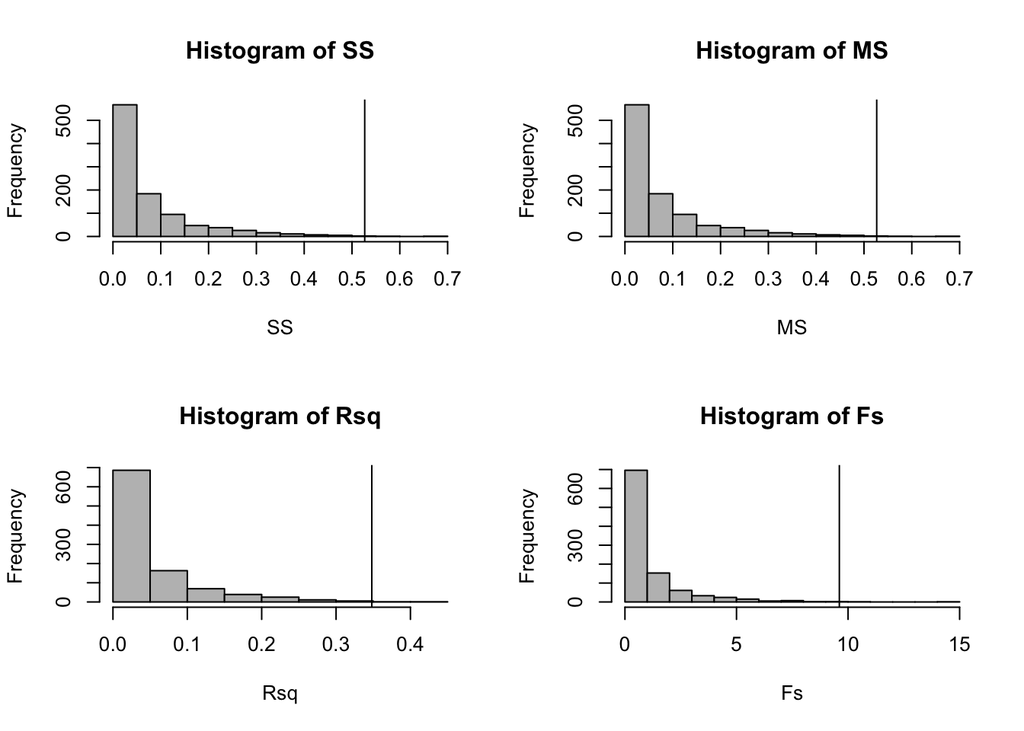

# RRPP and the Testing of Null Hypotheses

What these histograms tell us that for any of these model-comparison statistics, our observed values are rare in a sampling distribution from random outcomes **under the null hypothesis**. However, it was possible to randomly obtain statistics even greater than the ones we observe. We can even calculate the probabilities of randomly generating an outcome as or more excessive than our observed case, **by chance**.

```r
# Let's create a 2 x 2 plotting canvas
attach(fit1.rrpp$ANOVA)

# where our observed value ranks from small to large
rank(SS)[1]
```

```
## [1] 998
```

```r
# probability of finding a value larger
1 - rank(SS)[1] / length(SS)
```

```
## [1] 0.002
```

```r
# probability of finding a value as large or larger
1 - (rank(SS)[1] - 1) / length(SS)
```

```
## [1] 0.003
```

```r
# and likewise
1 - (rank(MS)[1] - 1) / length(MS)
```

```
## [1] 0.003
```

```r
1 - (rank(Rsq)[1] - 1) / length(Rsq)
```

```
## [1] 0.003
```

```r
1 - (rank(Fs)[1] - 1) / length(Fs)
```

```
## [1] 0.003
```

```r
detach(fit1.rrpp$ANOVA)
```

Notice that the probability of finding a random statistic as large as our observed was the same, regardless of the statistic we used. In fact, $SS$, $MS$, $R^2$, and $F$ are all perfectly **rank-order** correlated. What this means is that if permutation 532 gave us the smallest $SS$, it also gave us the smallest $MS$, $R^2$, and $F$. If we ordered the values for each statistic from small to large, the order would be the exact same in terms of the random permutations that produced the statistics. *This will not always be true when we start to consider more complex models with multiple hypotheses* but for now we can appreciate that these four statistics all (1) compare model $RSS$ and (2) can be used as **test statistics** for evaluating the null hypothesis.

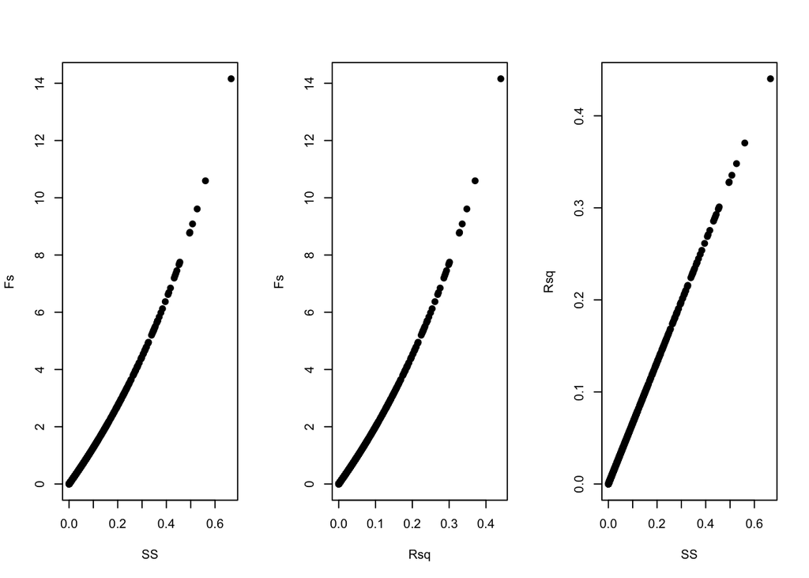

```r
attach(fit1.rrpp$ANOVA)
par(mfrow = c(1, 3))
plot(SS, Fs, pch = 19)
plot(Rsq, Fs, pch = 19)
plot(SS, Rsq, pch = 19)
```

```r
detach(fit1.rrpp$ANOVA)
```

# RRPP and the Testing of Null Hypotheses

### This is rejected

$$H_0: \sigma^2_{\beta_1, \mathbf{X}_1 | \beta_0, \mathbf{X}_0} = 0$$

### This is accepted

$$H_1: \sigma^2_{\beta_1, \mathbf{X}_1 | \beta_0, \mathbf{X}_0} > 0$$
Conclusion: The means between Mexico and USA snakes are **significantly different**. (This is incomplete, but we will discuss that next time.)